# Clustering Similar Candies

Venkat Somala

```r
library(ggplot2)  # for plots
library(dplyr)    # for wrangling
library(caret)    # for machine learning algorithms
    library(fivethirtyeight)
    data(candy_rankings)
    head(candy_rankings)
```

```
## # A tibble: 6 x 13
##   competitorname chocolate fruity caramel peanutyalmondy nougat
##   <chr>          <lgl>     <lgl>  <lgl>   <lgl>          <lgl>
## 1 100 Grand      TRUE      FALSE  TRUE    FALSE          FALSE
## 2 3 Musketeers   TRUE      FALSE  FALSE   FALSE          TRUE
## 3 One dime       FALSE     FALSE  FALSE   FALSE          FALSE
## 4 One quarter    FALSE     FALSE  FALSE   FALSE          FALSE
## 5 Air Heads      FALSE     TRUE   FALSE   FALSE          FALSE
## 6 Almond Joy     TRUE      FALSE  FALSE   TRUE           FALSE
## # … with 7 more variables: crispedricewafer <lgl>, hard <lgl>, bar <lgl>,
## #   pluribus <lgl>, sugarpercent <dbl>, pricepercent <dbl>,
## #   winpercent <dbl>
```

```
(@) **Process and get to know the data**
Here we are determining which of the variables in the dataset might be an identifying variable.
```

```r
library(tree)
candy_cluster <- hclust(dist(candy_rankings), method = "complete")
```

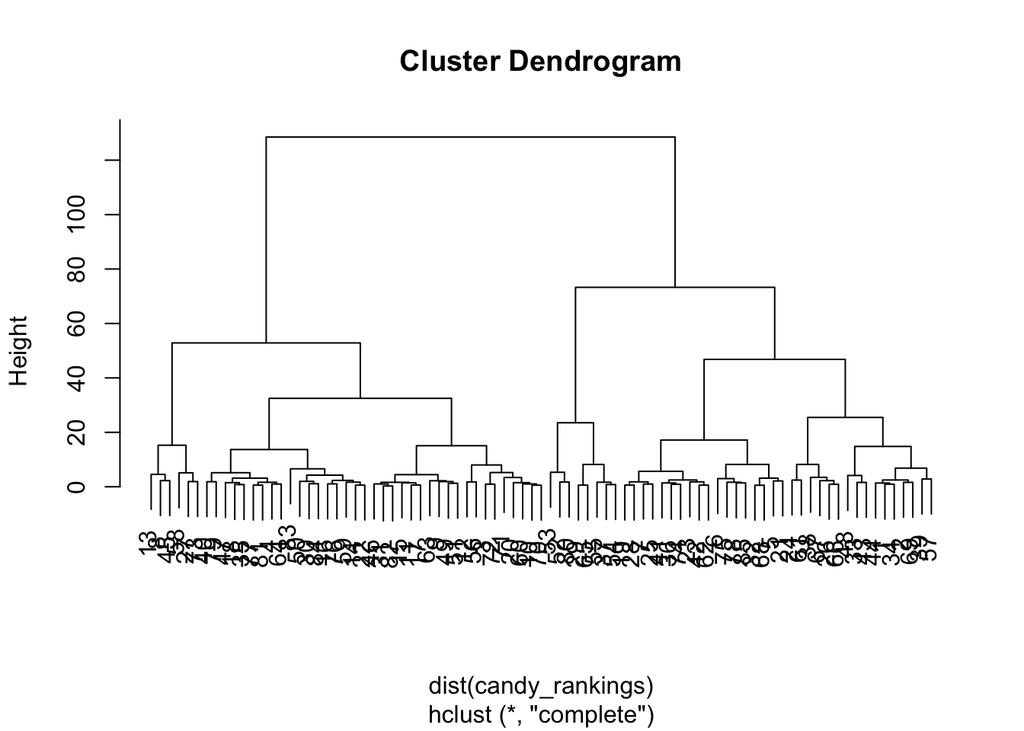

```r
plot(candy_cluster)
```

1. **Research Question**

What characterisitcs the most likeable candies share between each other. Maybe the caramel the candy, the more popular it is.

```
Now, we check out the scales of your features and we sacle these variables when we eventually conduct a hierarhical algorithm so that it converts all the variable values into the same scale, which makes it easier to compare and interpret.  Explain why it makes sense to *scale* these variables when you eventually conduct a hierarchical algorithm.
```

```r
library(tibble)
candy_cluster <- candy_rankings %>%
  column_to_rownames("competitorname")

hier_model <- hclust(dist(scale(candy_cluster)), method = "complete")
```

2. **Visualizing structure - Heat Map of Scaled Dataset**

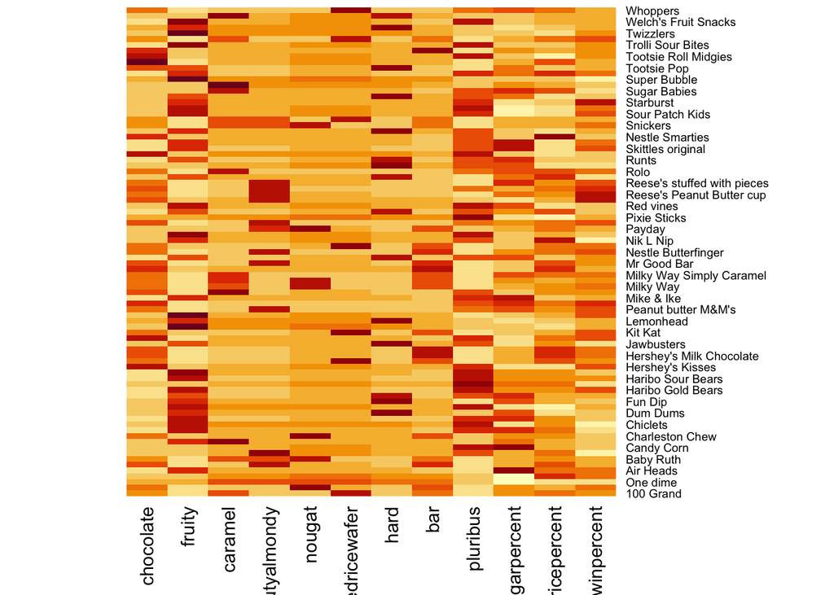

[output not shown]

```r
heatmap(data.matrix(scale(candy_cluster)), Colv = NA, Rowv = NA)
```

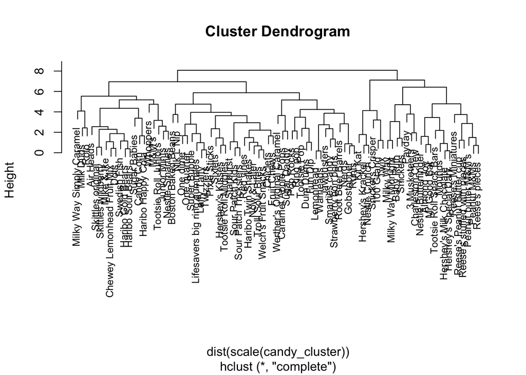

```r
plot(hier_model, cex=0.8)
```

3. **Defining & making meaning from clusters**

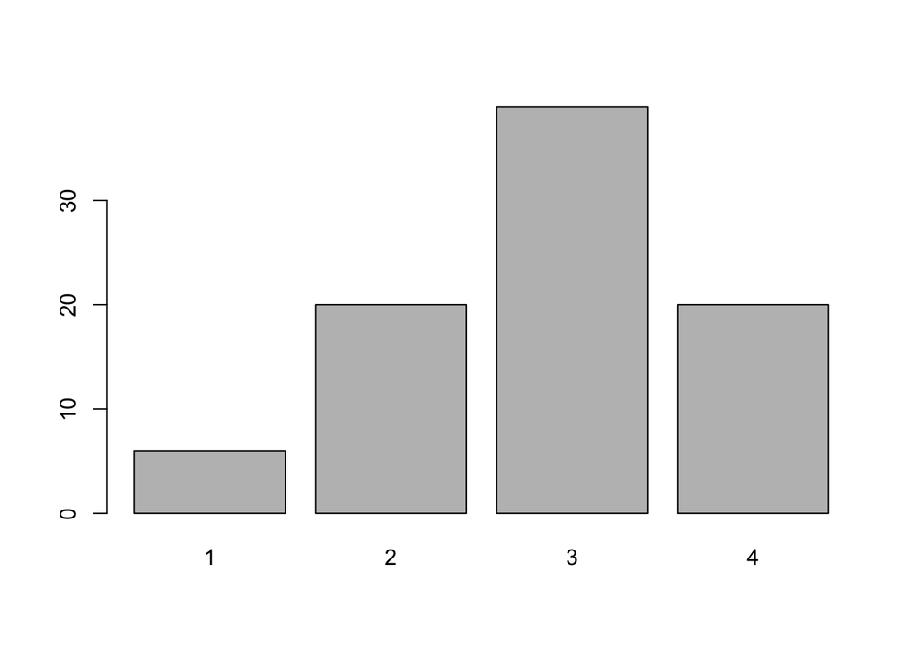

```r
cluster_4 <- as.factor(cutree(hier_model, k = 4))
plot(cluster_4)
```

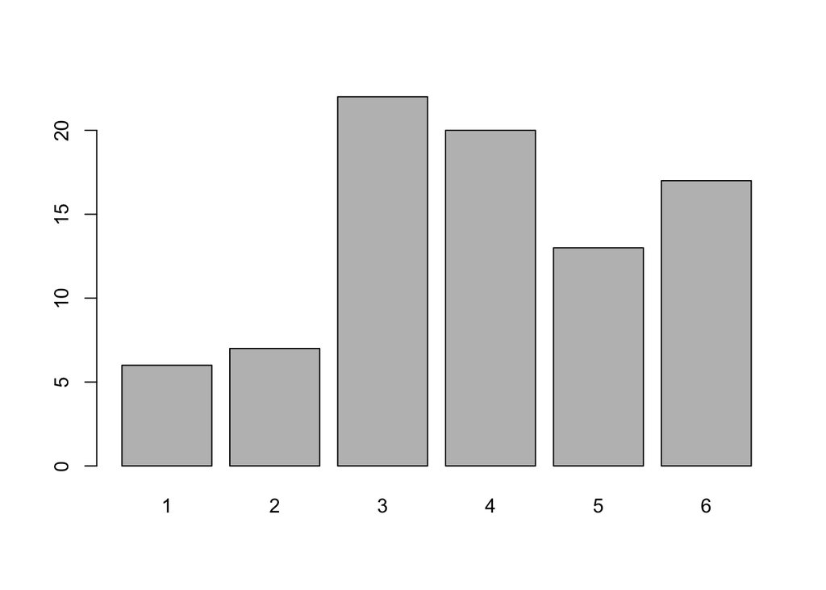

```r
cluster_6 <- as.factor(cutree(hier_model, k=6))
plot(cluster_6)
```

4. **Sensitivity analysis**  
   The hierarchical cluster analysis above utilized the **complete linkage** strategy to fuse branches. That is, we measured the distance between two branches by the *maximum* distance between any case in branch one and any case in branch two. This is merely one strategy. Consider 3 other strategies below.
1. Construct a dendrogram using the **single linkage** approach.

   Single finds the minimum distances between clusters whereas complete finds the maximum distance. THis one is a lot lower height is can be reduced to fewer clusters.

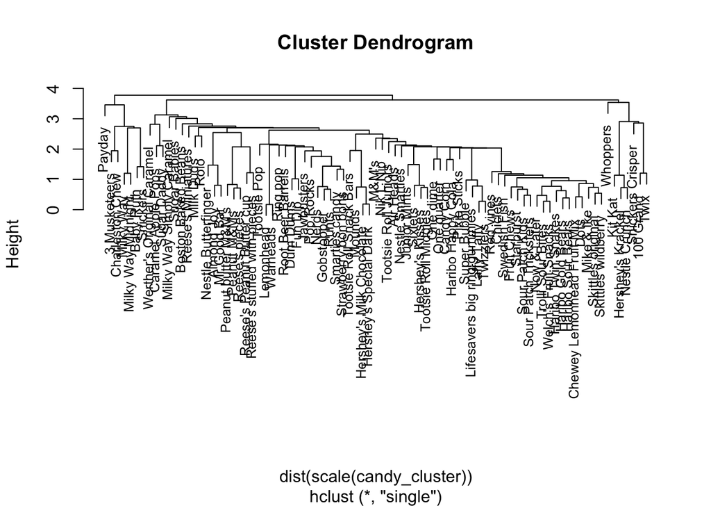

```r
hier_model_single <- hclust(dist(scale(candy_cluster)), method = "single")
plot(hier_model_single, cex=0.8)
```

2. **Centroid linkage**

   Centroid linkage finds the centroid of each cluster and calculate the distance between centroids of two clusters. This one has more clusters and is more scattered. one side is a lot more dense than the other in the original split.

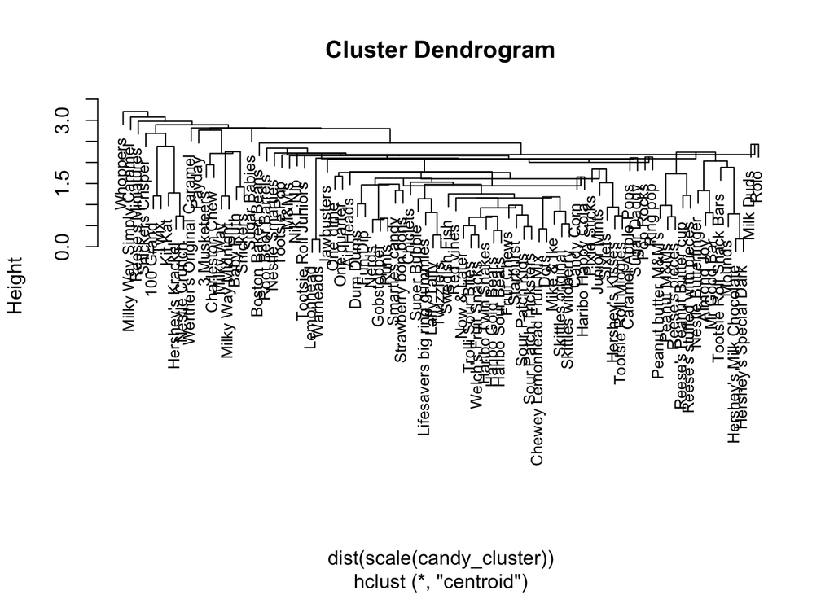

```r
hier_model_center <- hclust(dist(scale(candy_cluster)), method = "centroid")
plot(hier_model_center, cex=0.8)
```

3. **Average linkage**

   The average linkage finds all possible pair distances for points belonging to two different clusters and then calculates the average. This one is also lob sided but we can cut of the number of clusters at a smaller cluster number.

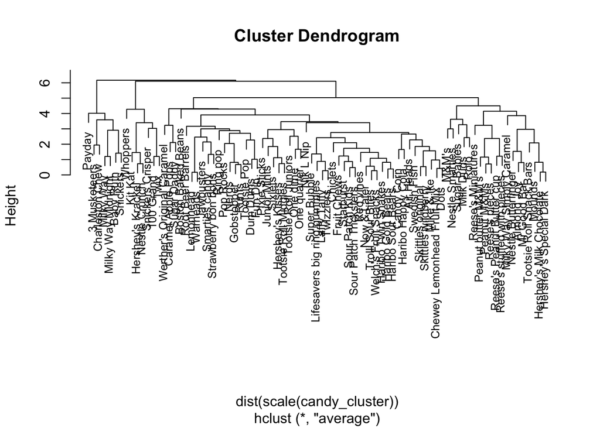

```
Complete linkage seems like the best type of linkage for this I would use the complete because it produces an even dendrogram that has a relatively small amount of clusters.
```

```r
hier_model_average <- hclust(dist(scale(candy_cluster)), method = "average")
plot(hier_model_average, cex=0.8)
```

5. **Choosing K**

Now let’s try the K-means approach. The first step is to **pick K**. So how do we choose?

```r
library(caret)
library(fivethirtyeight)
data(candy_rankings)
head(candy_rankings)
```

```
## # A tibble: 6 x 13
##   competitorname chocolate fruity caramel peanutyalmondy nougat
##   <chr>          <lgl>     <lgl>  <lgl>   <lgl>          <lgl>
## 1 100 Grand      TRUE      FALSE  TRUE    FALSE          FALSE
## 2 3 Musketeers   TRUE      FALSE  FALSE   FALSE          TRUE
## 3 One dime       FALSE     FALSE  FALSE   FALSE          FALSE
## 4 One quarter    FALSE     FALSE  FALSE   FALSE          FALSE
## 5 Air Heads      FALSE     TRUE   FALSE   FALSE          FALSE
## 6 Almond Joy     TRUE      FALSE  FALSE   TRUE           FALSE
## # … with 7 more variables: crispedricewafer <lgl>, hard <lgl>, bar <lgl>,
## #   pluribus <lgl>, sugarpercent <dbl>, pricepercent <dbl>,
## #   winpercent <dbl>
```

```r
library(tree)
candy_cluster <- hclust(dist(candy_rankings), method = "complete")
library(tibble)
candy_cluster <- candy_rankings %>%
  column_to_rownames("competitorname")

hier_model <- hclust(dist(scale(candy_cluster)), method = "complete")
```

```r
set.seed(253)
kmeans_model <- kmeans(scale(candy_cluster), centers = 3)
kmeans_model_2 <- kmeans(scale(candy_cluster), centers = 6)
SS <- rep(0, 2)
for(i in 1:2){
  SS[i] <- kmeans(scale(candy_cluster), centers = i)$tot.withinss
}
tune_data <- data.frame(K = 1:2, SS)

as.factor(kmeans_model$cluster)
```

```
##                   100 Grand                3 Musketeers
##                           1                           1
##                    One dime                 One quarter
##                           2                           2
##                   Air Heads                  Almond Joy
##                           2                           1
##                   Baby Ruth          Boston Baked Beans
##                           1                           2
##                  Candy Corn          Caramel Apple Pops
##                           2                           2
##             Charleston Chew  Chewey Lemonhead Fruit Mix
##                           1                           2
##                    Chiclets                        Dots
##                           2                           2
##                    Dum Dums                 Fruit Chews
##                           3                           2
##                     Fun Dip                  Gobstopper
##                           3                           3
##           Haribo Gold Bears           Haribo Happy Cola
##                           2                           2
##           Haribo Sour Bears          Haribo Twin Snakes
##                           2                           2
##            Hershey's Kisses           Hershey's Krackel
##                           2                           1
##    Hershey's Milk Chocolate      Hershey's Special Dark
##                           1                           1
##                  Jawbusters                Junior Mints
##                           3                           2
##                     Kit Kat                 Laffy Taffy
##                           1                           2
##                   Lemonhead Lifesavers big ring gummies
##                           3                           2
##         Peanut butter M&M's                       M&M's
##                           1                           1
##                  Mike & Ike                   Milk Duds
##                           2                           2
##                   Milky Way          Milky Way Midnight
##                           1                           1
##    Milky Way Simply Caramel                      Mounds
##                           1                           1
```

[output cut: 32 more lines]

```
##                Super Bubble                Swedish Fish
##                           2                           2
##                 Tootsie Pop        Tootsie Roll Juniors
##                           3                           2
##        Tootsie Roll Midgies     Tootsie Roll Snack Bars
##                           2                           1
##           Trolli Sour Bites                        Twix
##                           2                           1
##                   Twizzlers                    Warheads
##                           2                           3
##        Welch's Fruit Snacks  Werther's Original Caramel
##                           2                           3
##                    Whoppers
##                           1
## Levels: 1 2 3
```

2. One strategy for evaluating and comparing K is to calculate the total squared distance of each case from its assigned centroid (the `total within- cluster sum of squares`).

```r
kmeans_model$tot.withinss
```

```
## [1] 621.3659
```

3. Next, we calculate the total sum of squared distances for each K in $\{1, 2, ..., n\}$ where we pick a reasonable $n$.

```r
tune_data <- data.frame(K = 1:2, SS)
tune_data
```

```
##   K        SS
## 1 1 1008.0000
## 2 2  703.9851
```

6. **A final K-means model**  
   We run the K-means algorithm using the K we identified earlier. Store the cluster labels in the data set.

```r
SS_2 <- rep(0, 18)
for(i in 1:18){
  SS_2[i] <- kmeans(scale(candy_cluster), centers = i)$tot.withinss
}
tune_data_2 <- data.frame(K = 1:18, SS_2)

candy_cluster %>% mutate(as.factor(kmeans_model$cluster))
```

```
##    chocolate fruity caramel peanutyalmondy nougat crispedricewafer  hard
## 1       TRUE  FALSE    TRUE          FALSE  FALSE             TRUE FALSE
## 2       TRUE  FALSE   FALSE          FALSE   TRUE            FALSE FALSE
## 3      FALSE  FALSE   FALSE          FALSE  FALSE            FALSE FALSE
## 4      FALSE  FALSE   FALSE          FALSE  FALSE            FALSE FALSE
## 5      FALSE   TRUE   FALSE          FALSE  FALSE            FALSE FALSE
## 6       TRUE  FALSE   FALSE           TRUE  FALSE            FALSE FALSE
## 7       TRUE  FALSE    TRUE           TRUE   TRUE            FALSE FALSE
## 8      FALSE  FALSE   FALSE           TRUE  FALSE            FALSE FALSE
## 9      FALSE  FALSE   FALSE          FALSE  FALSE            FALSE FALSE
## 10     FALSE   TRUE    TRUE          FALSE  FALSE            FALSE FALSE
## 11      TRUE  FALSE   FALSE          FALSE   TRUE            FALSE FALSE
## 12     FALSE   TRUE   FALSE          FALSE  FALSE            FALSE FALSE
## 13     FALSE   TRUE   FALSE          FALSE  FALSE            FALSE FALSE
## 14     FALSE   TRUE   FALSE          FALSE  FALSE            FALSE FALSE
```

[output cut: 243 more lines]

```r
tune_data_2
```

```
##     K      SS_2
## 1   1 1008.0000
## 2   2  703.9851
## 3   3  637.2731
## 4   4  580.5499
## 5   5  451.8226
## 6   6  404.0259
## 7   7  460.4268
## 8   8  357.8766
## 9   9  307.6470
## 10 10  295.8493
## 11 11  281.6885
## 12 12  258.7438
## 13 13  258.7426
## 14 14  233.8311
## 15 15  222.3764
## 16 16  225.8736
## 17 17  194.9466
## 18 18  196.0123
```

```r
  kmeans_model_2$withinss
```

```
## [1]  78.57306  35.08662  89.36640 118.75488  65.46992  34.13899
```

```r
head(candy_cluster)
```

```
##              chocolate fruity caramel peanutyalmondy nougat
## 100 Grand         TRUE  FALSE    TRUE          FALSE  FALSE
## 3 Musketeers      TRUE  FALSE   FALSE          FALSE   TRUE
## One dime         FALSE  FALSE   FALSE          FALSE  FALSE
## One quarter      FALSE  FALSE   FALSE          FALSE  FALSE
## Air Heads        FALSE   TRUE   FALSE          FALSE  FALSE
## Almond Joy        TRUE  FALSE   FALSE           TRUE  FALSE
##              crispedricewafer  hard   bar pluribus sugarpercent
## 100 Grand                TRUE FALSE  TRUE    FALSE        0.732
## 3 Musketeers            FALSE FALSE  TRUE    FALSE        0.604
## One dime                FALSE FALSE FALSE    FALSE        0.011
## One quarter             FALSE FALSE FALSE    FALSE        0.011
## Air Heads               FALSE FALSE FALSE    FALSE        0.906
## Almond Joy              FALSE FALSE  TRUE    FALSE        0.465
##              pricepercent winpercent
## 100 Grand           0.860   66.97173
## 3 Musketeers        0.511   67.60294
## One dime            0.116   32.26109
## One quarter         0.511   46.11650
## Air Heads           0.511   52.34146
## Almond Joy          0.767   50.34755
```

8. **Principal components analysis**  
   We have quite a few features in your dataset. We can perform a useful dimension reducation via PCA.

```r
candy_nowin <- candy_cluster %>% select(-"winpercent")

# Compute PCA
pca_results <- prcomp(candy_nowin, scale = TRUE)

# Loadings (ie. definition of PCs)
pca_results$rotation
```

```
##                         PC1         PC2         PC3         PC4
## chocolate        -0.4108662  0.21740236 -0.07367612  0.03080335
## fruity            0.3958992 -0.26069583 -0.01334054 -0.06923952
## caramel          -0.2522898 -0.39874749 -0.01962328 -0.03862553
## peanutyalmondy   -0.2421395  0.23192057  0.20248013  0.45441432
## nougat           -0.2505358 -0.33209030  0.52893191  0.14935275
## crispedricewafer -0.2287828  0.02336145 -0.51840794 -0.49204868
## hard              0.2172832 -0.49780524 -0.01311721 -0.11399766
## bar              -0.4246558 -0.12831774  0.10346994 -0.21942543
## pluribus          0.2848606  0.21680859 -0.30355746  0.40878040
## sugarpercent     -0.1038562 -0.49896801 -0.41539256  0.50519217
## pricepercent     -0.3429068 -0.03011511 -0.35905239  0.19593637
##                          PC5         PC6         PC7         PC8
## chocolate        -0.08236125  0.12184878 -0.48511279  0.02384081
## fruity           -0.07628294 -0.35070344  0.41272241 -0.02092286
## caramel           0.52640570  0.59218305  0.26620561  0.08889254
## peanutyalmondy   -0.44568311  0.26885853  0.46430139 -0.36312121
## nougat            0.22275924 -0.35149766 -0.17714020 -0.33313353
## crispedricewafer -0.02404426 -0.05104141  0.15578026 -0.57870373
## hard             -0.55174148  0.33405346 -0.39369684 -0.08038925
## bar              -0.07908975 -0.34381552 -0.03210197 -0.04688733
## pluribus          0.35421215 -0.05175213 -0.28334896 -0.33485706
## sugarpercent     -0.03922886 -0.13259924 -0.02824700 -0.10908916
## pricepercent     -0.15421519 -0.25095178  0.12298857  0.52978152
##                          PC9        PC10        PC11
## chocolate        -0.14653170  0.66558792  0.23566084
## fruity            0.09592179  0.67093829  0.10668030
## caramel           0.16952920  0.18571962 -0.07543422
## peanutyalmondy    0.11721967  0.06910818 -0.05677309
## nougat            0.22040317 -0.10800392  0.38613640
## crispedricewafer  0.07878386 -0.10911849  0.23620200
## hard              0.33379917 -0.02198341 -0.04934822
## bar               0.07225016  0.12218271 -0.77233834
## pluribus          0.45502641  0.10742194 -0.27101842
## sugarpercent     -0.52345689 -0.06608491 -0.04775548
## pricepercent      0.52379795 -0.11259022  0.21119596
```

1. Here we construct a scree plot.

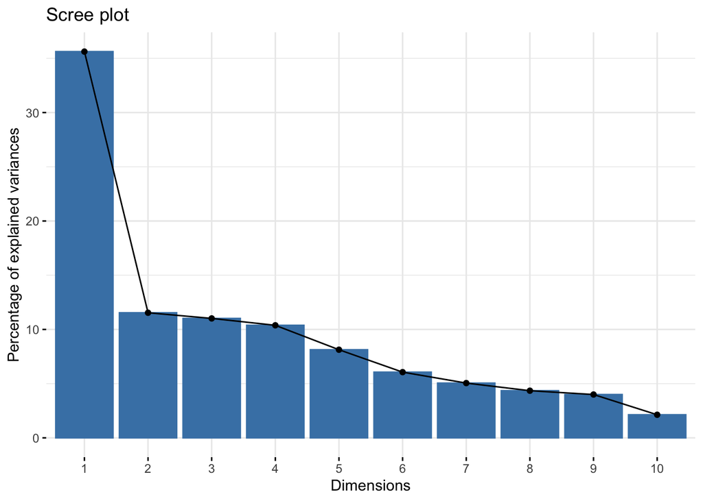

```r
# Scree plot: % of variance explained by each principal component
library(factoextra)
fviz_eig(pca_results)
```

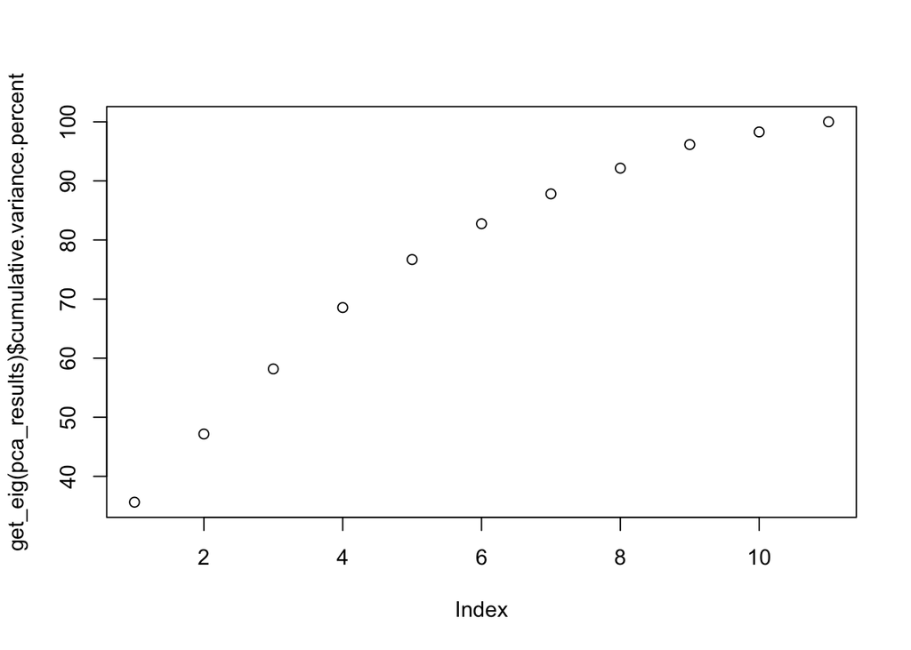

```r
# Plot cumulative % of variance explained
plot(get_eig(pca_results)$cumulative.variance.percent)
```

```r
# Numerical examination
get_eig(pca_results)
```

```
##        eigenvalue variance.percent cumulative.variance.percent
## Dim.1   3.9187452        35.624956                    35.62496
## Dim.2   1.2692196        11.538360                    47.16332
## Dim.3   1.2118369        11.016699                    58.18002
## Dim.4   1.1419752        10.381593                    68.56161
## Dim.5   0.8941622         8.128748                    76.69036
## Dim.6   0.6668683         6.062439                    82.75279
## Dim.7   0.5557406         5.052188                    87.80498
## Dim.8   0.4784604         4.349640                    92.15462
## Dim.9   0.4397143         3.997402                    96.15202
## Dim.10  0.2344714         2.131558                    98.28358
## Dim.11  0.1888059         1.716417                   100.00000
```

2. We construct a score plot.

Chocolate peanut better is in top left. Chocolate is bottom left. More fruity is top right and more hard and fruity is bottom right.

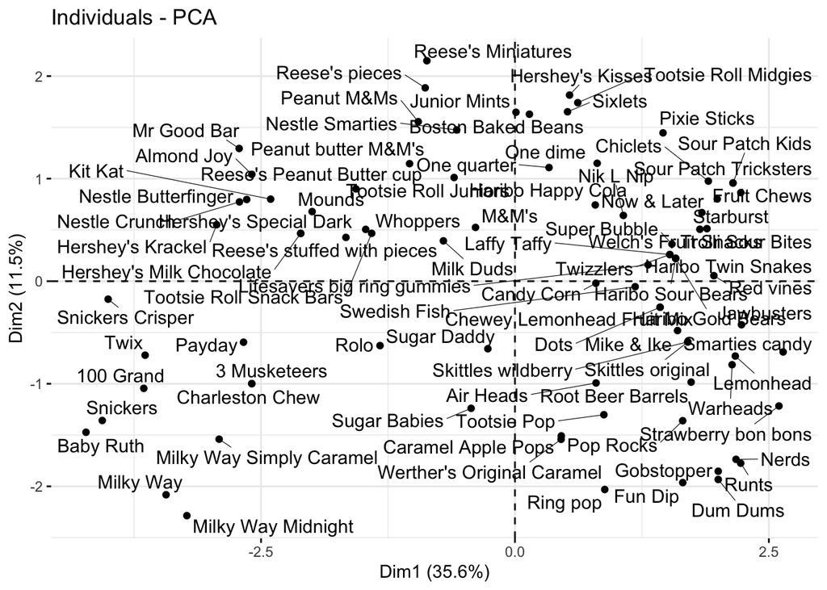

```r
# Score plot: plot PC1 scores vs PC2 scores
fviz_pca_ind(pca_results, repel = TRUE)
```

3. We construct a **loadings plot**

```r
# Loadings plot
fviz_pca_var(pca_results, repel = TRUE)
```

[output not shown]

9. **Principal components regression**  
   In this exercise we will perform principal components regression for $y$.

```r
library(caret)
library(fivethirtyeight)
data(candy_rankings)
head(candy_rankings)
```

```
## # A tibble: 6 x 13
##   competitorname chocolate fruity caramel peanutyalmondy nougat
##   <chr>          <lgl>     <lgl>  <lgl>   <lgl>          <lgl>
## 1 100 Grand      TRUE      FALSE  TRUE    FALSE          FALSE
## 2 3 Musketeers   TRUE      FALSE  FALSE   FALSE          TRUE
## 3 One dime       FALSE     FALSE  FALSE   FALSE          FALSE
## 4 One quarter    FALSE     FALSE  FALSE   FALSE          FALSE
## 5 Air Heads      FALSE     TRUE   FALSE   FALSE          FALSE
## 6 Almond Joy     TRUE      FALSE  FALSE   TRUE           FALSE
## # … with 7 more variables: crispedricewafer <lgl>, hard <lgl>, bar <lgl>,
## #   pluribus <lgl>, sugarpercent <dbl>, pricepercent <dbl>,
## #   winpercent <dbl>
```

```r
library(tree)
candy_cluster <- hclust(dist(candy_rankings), method = "complete")
```

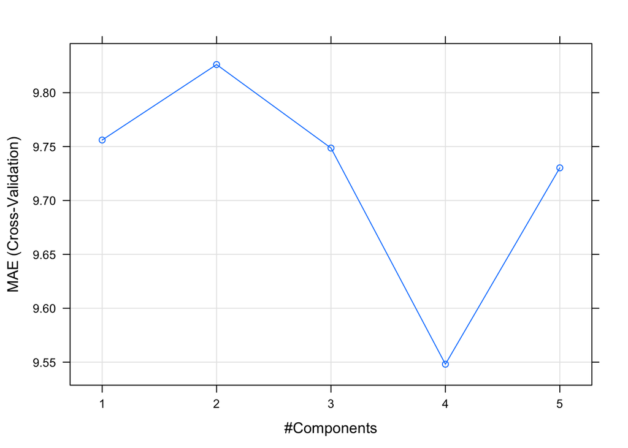

```r
library(tibble)
candy_cluster <- candy_rankings %>%
  column_to_rownames("competitorname")

hier_model <- hclust(dist(scale(candy_cluster)), method = "complete")


# Set the seed
set.seed(253)

# Run the algorithm
pcr_model <- train(
  winpercent ~ .,
  data = candy_cluster,
  method = "pcr",
  scale = TRUE,
  tuneGrid = data.frame(ncomp = 1:5),  # number of PCs to keep as predictors
  trControl = trainControl("cv", number = 10, selectionFunction = "oneSE"),
  metric = "MAE"
)

# CV metrics by number of PCs
plot(pcr_model)
```

```r
pcr_model$results
```

```
##   ncomp     RMSE  Rsquared      MAE   RMSESD RsquaredSD    MAESD
## 1     1 11.91983 0.3697331 9.756087 1.716672  0.1858384 1.510205
## 2     2 11.88149 0.3712643 9.826124 1.832493  0.1761292 1.701233
## 3     3 11.90058 0.3627448 9.748641 2.163314  0.1786692 1.911637
## 4     4 11.79580 0.3658765 9.548093 2.162562  0.1712402 1.985936
## 5     5 11.93489 0.3540514 9.730294 2.412922  0.1909888 2.173016
```

```r
# Variation in original predictors explained by each PC
summary(pcr_model)
```

```
## Data:    X dimension: 85 11
##  Y dimension: 85 1
## Fit method: svdpc
## Number of components considered: 1
## TRAINING: % variance explained
##           1 comps
## X           35.62
## .outcome    33.83
```

```r
head(candy_cluster)
```

```
##              chocolate fruity caramel peanutyalmondy nougat
## 100 Grand         TRUE  FALSE    TRUE          FALSE  FALSE
## 3 Musketeers      TRUE  FALSE   FALSE          FALSE   TRUE
## One dime         FALSE  FALSE   FALSE          FALSE  FALSE
## One quarter      FALSE  FALSE   FALSE          FALSE  FALSE
## Air Heads        FALSE   TRUE   FALSE          FALSE  FALSE
## Almond Joy        TRUE  FALSE   FALSE           TRUE  FALSE
##              crispedricewafer  hard   bar pluribus sugarpercent
## 100 Grand                TRUE FALSE  TRUE    FALSE        0.732
## 3 Musketeers            FALSE FALSE  TRUE    FALSE        0.604
## One dime                FALSE FALSE FALSE    FALSE        0.011
## One quarter             FALSE FALSE FALSE    FALSE        0.011
## Air Heads               FALSE FALSE FALSE    FALSE        0.906
## Almond Joy              FALSE FALSE  TRUE    FALSE        0.465
##              pricepercent winpercent
## 100 Grand           0.860   66.97173
## 3 Musketeers        0.511   67.60294
## One dime            0.116   32.26109
## One quarter         0.511   46.11650
## Air Heads           0.511   52.34146
## Almond Joy          0.767   50.34755
```

```r
set.seed(253)
lambda_grid <- seq(0, 1, length = 100)


lasso_model_2 <- train(
    winpercent ~ .,
    data = candy_cluster,
    method = "glmnet",
    tuneGrid = data.frame(alpha = 1, lambda = lambda_grid),
    trControl = trainControl(method = "cv", number = 10, selectionFunction = "best"),
    metric = "MAE",
    na.action = na.omit
)

coef(lasso_model_2$finalModel, lasso_model_2$bestTune$lambda) #oneSE
```

```
## 12 x 1 sparse Matrix of class "dgCMatrix"
##                                1
## (Intercept)          37.99529386
## chocolateTRUE        15.48022718
## fruityTRUE            3.30211268
## caramelTRUE           0.21153100
## peanutyalmondyTRUE    7.26386692
## nougatTRUE            .
## crispedricewaferTRUE  6.15897327
## hardTRUE             -3.39999268
## barTRUE               .
## pluribusTRUE         -0.02087903
## sugarpercent          6.22407389
## pricepercent          .
```

```r
lasso_model_2$bestTune$lambda
```

```
## [1] 0.6060606
```

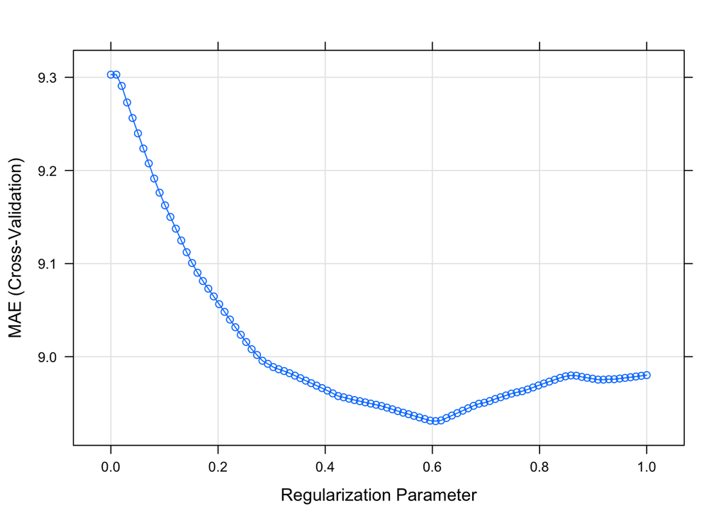

```
In the optimally tuned LASSO model, there are 8 predictors.
```

```r
plot(lasso_model_2)
```

3. We report the 10-fold CV MAE for the optimally tuned LASSO model.

```r
lasso_model_2$resample
```

```
##         RMSE  Rsquared       MAE Resample
## 1   9.060705 0.4652186  7.633885   Fold01
## 2  10.417977 0.5664095  8.326282   Fold10
## 3  11.405492 0.2951101  8.451525   Fold08
## 4  10.007884 0.4652922  7.727180   Fold04
## 5  10.295582 0.3405933  8.386983   Fold06
## 6  15.827480 0.2387633 13.601954   Fold03
## 7   9.052159 0.8196754  6.909666   Fold07
## 8  11.063978 0.5099477  9.419892   Fold02
## 9  10.450285 0.3901884  7.880982   Fold05
## 10 12.502720 0.6935619 10.970107   Fold09
```